# Cryptocurrency Analysis

group 4

12/6/2021

> Group member: Shuren He, Suhui Liu, Kelly Zihan Zhao, Jiaying Jia

> Github: https://github.com/zzh611/cryptocurrency

## 1. Background and Data Introduction

In recent years, with the popularity of Bitcoin, a variety of cryptocurrencies have emerged. Because of the volatility of cryptocurrency, investors have difficulty in choosing which cryptocurrency to invest in. To solve this problem, our group decided to use large scale computing and time series models to predict the future trend of cryptocurrency.

Our data sourced from Kaggle. It is a collection of 1 minute candlesticks of the top 1000 cryptocurrency pairs on Binance.com. This time series data set recorded the price ratio between a bunch of new cryptocurrencies and some specific famous cryptocurrencies. (For example, 1INCH/BTC, 1INCH/BUSD, AAVE/BNB etc.) Cryptocurrency pairs allow investors to compare costs between different cryptocurrencies. These pairings help illustrate the relative worth of coins — for example, how much Bitcoin (BTC) equals in Ethereum (ETH) and how much ETH equals in Bitcoin Cash (BCH).Exchanges usually offer several pairing options, giving you the chance to choose a pairing based on currencies you already possess. This means that the dataset for our project is meaningful and practical.

There are two main reasons: Some cryptocurrencies can only be bought with other cryptocurrencies, so knowledge of cryptocurrency pairs is necessary to expand your crypto holdings beyond the most common coins; and, knowledge of crypto trading pairs gives savvy crypto investors the chance to exploit arbitrage opportunities — the chance to profit from differences in asset prices between markets.

As for details of the dataset, there are 10 columns in total. In our project, we mainly use the “open” (1-minute candlestick data of cryptocurrency pairs prices ratio) column and the “open_time” (the time that starts recording with 1 minute, eg. 2021-02-26 04:00:00, 2021-02-26 04:01:00) column.

## 2. Variance fluctuation

We want to find the most stable and most volatile pair from 1000 cryptocurrency pairs. Stable currencies means a close relationship between 2 types of crypto. Volatile currencies means you will make a lot of profit or loss. We use variance to measure the level of fluctuation, which can help people make decisions for their investment.

We use the currency between 2020-01-01 23:00:00 CST and 2021-01-01 23:00:00 CST to calculate the variance for each pair. The most stable pair is HBAR-USDT and the most volatile pair is BTC-BIDR. After we run 1000 parallel jobs on CHTC, we find the most stable pair is HBAR-USDT and the most volatile pair is BTC-BIDR.

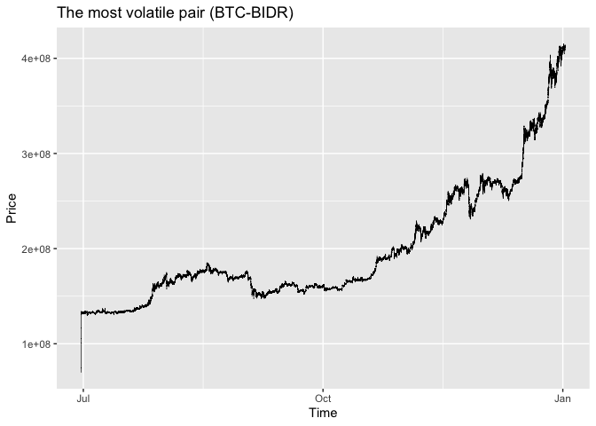

```r
volatile <- read_parquet("BTC-BIDR.parquet", as_tibble = TRUE)
volatile <- volatile[which(volatile$open_time >= '2020-01-01 23:00:00 CST'),]
volatile <- volatile[which(volatile$open_time <= '2021-01-01 23:00:00 CST'),]
ggplot(volatile, aes(x=open_time)) +
  geom_line(aes(y=open),size=0.2) +
  ggtitle("The most volatile pair (BTC-BIDR)") +
  ylab("Price") +
  xlab("Time")
```

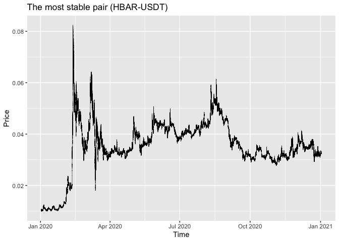

```r
stable <- read_parquet("HBAR-USDT.parquet", as_tibble = TRUE)
stable <- stable[which(stable$open_time >= '2020-01-01 23:00:00 CST'),]
stable <- stable[which(stable$open_time <= '2021-01-01 23:00:00 CST'),]
ggplot(stable, aes(x=open_time)) +
  geom_line(aes(y=open),size=0.2) +
  ggtitle("The most stable pair (HBAR-USDT)") +
  ylab("Price") +
  xlab("Time")
```

## 3. Time Series Model

### RNN Model:

#### Show the outcome of RNN

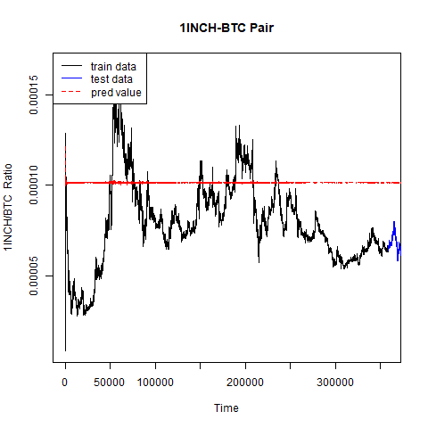

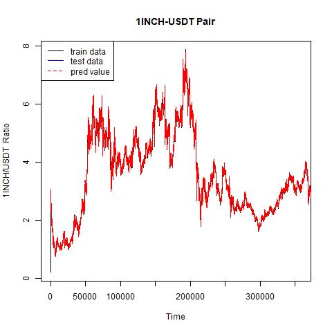

### ARIMA Model:

#### Show the outcome of ARIMA

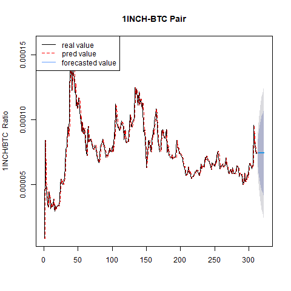

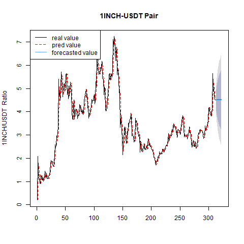

Our group use two methods to train the time seires model: RNN model and ARIMA model. The plots above show the outcomes of these two methods. According to the plot, we found that the effects of RNN model is not stable. If the ratio of the cryptocurrency pairs is extremely small, the predictive values of RNN time series model will strongly depert from the true value. For example, the 1INCH-BTC pair. On the contrary, the results of the RNN models are good. However, the outcomes of the ARIMA models are stable. So, our group decided to adopt the ARIMA model to predict the trends of different cryptocurrency pairs.

## Test whether the time series data is white noise.

```r
x <- dat$open
for (i in 1:2) print(Box.test(x, type='Ljung-Box', lag=6*i))
```

```
##
##  Box-Ljung test
##
## data:  x
## X-squared = 2764641, df = 6, p-value < 2.2e-16
##
##
##  Box-Ljung test
##
## data:  x
## X-squared = 5527881, df = 12, p-value < 2.2e-16
```

If the time series data not passing the test denotes this data is white noise and there is not need to train the ARIMA model on this data. Here the p-value is less than 0.05 and we will apply further analysis on this data.

## Automatically choose proper parameters.

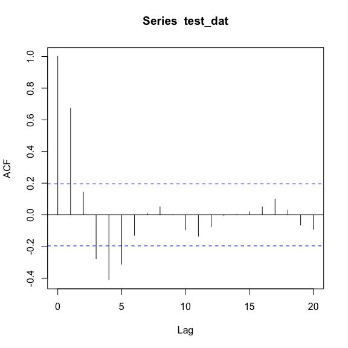

```r
test_dat <- arima.sim(n=100,list(ar=c(1,-0.5)))
acf(test_dat)
```

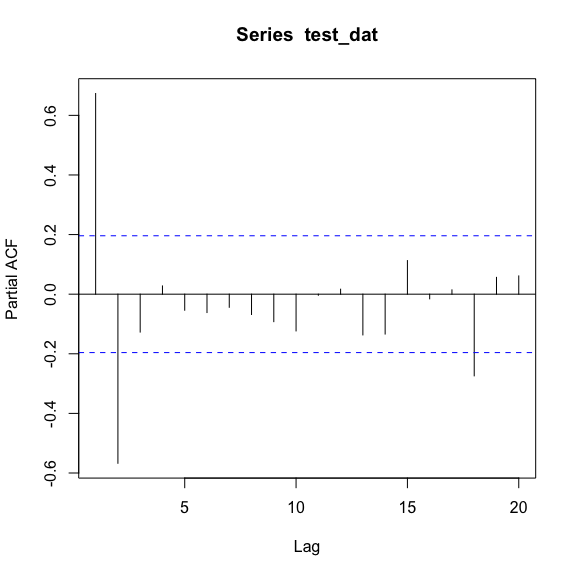

```r
pacf(test_dat)
```

For ARIMA Model, we need to decide the parameter for AR order, the degree of differencing, and the MA order. Usually, we decide the these parameters by ACF and PACF plots. If the ACF plot is trailing and PACF plot is truncated. We will adopt AR model. On the contrary, we will use MA model.If both ACF and PACF plots are trailing, we will use ARMA model. However, if we want to run parallel jobs in CHTC, it is impossible for us to choose the parameter setting by plots. So we need another methods to choose the parameter automatically.

### Choose the parameter based on AIC criterion.

```r
auto.model <- auto.arima(test_dat,max.p = 5, max.q = 5,ic = 'aic')
summary(auto.model)
```

```
## Series: test_dat
## ARIMA(2,0,0) with zero mean
##
## Coefficients:
##          ar1      ar2
##       1.0649  -0.5642
## s.e.  0.0816   0.0813
##
## sigma^2 estimated as 0.7818:  log likelihood=-129.27
## AIC=264.55   AICc=264.8   BIC=272.36
##
## Training set error measures:
##                      ME      RMSE       MAE      MPE     MAPE      MASE
## Training set 0.09147754 0.8753281 0.6956738 942.8553 1021.525 0.7444018
##                     ACF1
## Training set -0.07390671
```

We use auto.arima to decide the setting of parameters which is based on AIC criterion.

As it can be seen from the plot, RNN is good at predicting the trend of fluctuating data, but it’s not good at predicting smooth data. So we finally decided to use the ARIMA model to predict the ratio of cryptocurrency pairs for 10 days, and then calculated the difference between the 10th and the first day. If the difference is larger than 0, we choose the second part of the pair. On the contrary, if it’s less than 0, then the first one is preferred. Then, we aggregated all the preferred cryptocurrencies and the differences, and calculated a score value. The function of score is: $score_j=\frac{1}{choice(j)}\sum_{i=1}^{1000}|forecast_{10ij}-forecast_{1ij}|\times\frac{choice(j)}{n(j)}=\frac{\sum_{i=1}^{1000}|forecast_{10ij}-forecast_{1ij}|}{n(j)}$, where i means the serial number of the cryptopair, j means a specific cryptocurrency.

```
##     X choice          avg count   n        score
## 1   1    TRY 1.878780e+03     4  16 4.696950e+02
## 2   2    ETH 5.163736e+02    70 152 2.378036e+02
## 3   3    YFI 3.078058e+02     3   4 2.308543e+02
## 4   4    DOT 2.477071e+02     4   6 1.651381e+02
## 5   5    BNB 2.369143e+02    50 135 8.774605e+01
## 6   6    BTC 6.186372e+01    62 266 1.441936e+01
## 7   7    NGN 3.806257e+00     2   3 2.537505e+00
## 8   8    BCH 3.177492e+00     5   7 2.269637e+00
## 9   9    EUR 9.247898e+00     3  17 1.631982e+00
## 10 10   BUSD 2.342503e+00    44 130 7.928473e-01
## 11 11    HNT 6.783851e-01     2   2 6.783851e-01
## 12 12   TUSD 1.938195e+00     5  16 6.056859e-01
## 13 13   USDT 1.368228e+00    87 260 4.578301e-01
## 14 14   USDC 1.309942e+00     5  16 4.093569e-01
```

[output cut: 72 more lines]

## 4. Computational Steps

The dataset is too large(25G) for a personal workspace(20G) on CHTC. So first, we applied for a shared folder by emailing CHTC and they helped us increase the memory of this folder(50G). Then we wrote two sets of .sub file and .sh file to run 1000 jobs in parallel. The first set of code was responsible for finding the most stable/volatile pair in 1000 pairs. And the second set of code produced the predicting results for 1000 cryptocurrency pairs in 10 days.Here are some of the results:

## 5. Conclusion

We listed the top 10 stable pairs and the top 10 volatile pairs. For risk avoiders, cryptocurrency pairs like: HBAR-USDT, FTM-USDT, USDT-DAI might be your first choices. As for the risk preference people, BTC-BIDR, BTC-IDRT, BTC-NGN might be better choices.

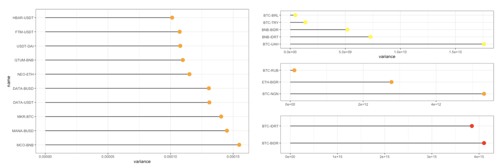

As for the prediction part, we use the RNN method to fit a model for the price ratio of cryptocurrency pairs. Generally, RNN performed wel in volatile data. But when the data is stable, the result is bad. Thus, we choose the ARIMA model to fit the dataset which does well in both situations.

After deciding which method to use for our dataset, we use large scale computing on CHTC and run 1000 jobs in parallel and get the predicting result for 1000 cryptocurrency pairs.